# Baza danych

Baza danych **AutoSprzedam.dat**. Baza pochodzi z zasobów zgormadzonych na ePortalu.

## Zawartość

Baza danych zawiera 41034 rekordów zawierających szczegółowe dane dotyczące sprzedaży samochodów m.in.

| Kolumna | Typ danych | Opis |
| --- | --- | --- |
| NrOferty | int | Numer oferty sprzedaży samochodu. |
| CenaPLN | string | Cena samochodu wyrażona w polskich złotych (PLN). |
| KM | int | Liczba koni mechanicznych samochodu. |
| Marka | string | Marka samochodu. |
| Model | string | Model samochodu. |
| LiczbaDrzwi | string | Liczba drzwi w samochodzie. |
| PojemnoscSkokowa | int | Pojemność skokowa silnika wyrażona w centymetrach sześciennych (cm³). |
| PrzebiegKm | int | Przebieg samochodu wyrażony w kilometrach. |
| RodzajPaliwa | string | Rodzaj paliwa używanego przez samochód (benzyna, diesel, hybryda, elektryczny itp.). |
| RokProdukcji | int | Rok produkcji samochodu. |
| Kolor | string | Kolor samochodu. |
| KrajPochodzenia | string | Kraj pochodzenia samochodu. |
| PojazdUszkodzony | string | Informacja czy pojazd jest uszkodzony (Tak/Nie). |
| SkrzyniaBiegow | string | Typ skrzyni biegów w samochodzie (manualna, automatyczna). |

## Podstawowe dana dotyczące bazy danych

```
## Liczba rekordów: 41034 , liczba kolumn: 14
```

```
## - Przykład  5 pierwszych rekordów.
```

```
##   NrOferty CenaPLN  KM         Marka         Model LiczbaDrzwi PojemnoscSkokowa
## 1        1   27900 150          Opel        Vectra         4/5             1900
## 2        2   28000 116        Toyota Corolla Verso         4/5             2000
## 3        3   25500 150         Skoda        Superb         4/5             1781
## 4        4   29900 109 Mercedes-Benz         A 180         2/3             1991
## 5        5   29800 207       Peugeot           607         4/5             2946
##   PrzebiegKm           RodzajPaliwa RokProdukcji              Kolor
## 1      80840 olej napędowy (diesel)         2005    czarny-metallic
## 2     166000 olej napędowy (diesel)         2004              bialy
## 3     112000            benzyna+LPG         2002   bordowy-metallic
## 4      42000 olej napędowy (diesel)         2005           czerwony
## 5     169000                benzyna         2004 granatowy-metallic
##   KrajPochodzenia PojazdUszkodzony SkrzyniaBiegow
## 1          Niemcy              Nie       manualna
## 2          Polska              Nie       manualna
## 3          Polska              Nie       manualna
## 4          Polska              Nie       manualna
## 5         Francja              Nie       manualna
```

```
## -  Przykład  5 ostatnich rekordów.
```

```
##       NrOferty  CenaPLN  KM         Marka    Model LiczbaDrzwi PojemnoscSkokowa
## 41030    41030 98000.00 220          Opel Insignia         4/5             1998
## 41031    41031 34924.50 184 Mercedes-Benz    S 400         4/5             3996
## 41032    41032 41175.09  70       Peugeot      308         2/3             1397
## 41033    41033 47900.00 115          Ford    C-MAX         4/5             1560
## 41034    41034 14200.00  90          Ford   Mondeo         4/5             1998
##       PrzebiegKm           RodzajPaliwa RokProdukcji              Kolor
## 41030      25500                benzyna         2010 grafitowy-metallic
## 41031     162000 olej napędowy (diesel)         2001   srebrny-metallic
## 41032       9289                benzyna         2010   srebrny-metallic
## 41033      45000 olej napędowy (diesel)         2010    czarny-metallic
## 41034     191024 olej napędowy (diesel)         2003    czarny-metallic
##       KrajPochodzenia PojazdUszkodzony SkrzyniaBiegow
## 41030          Polska              Nie       manualna
## 41031          Czechy              Nie   automatyczna
## 41032          Niemcy              Nie       manualna
## 41033          Belgia              Nie       manualna
## 41034          Niemcy              Nie       manualna
```

# Przygotowanie bazy danych

Przed przejściem do dalszej pracy z bazą danych konieczne jest jej przygotowanie.

## Pole - *SkrzyniaBiegow*

W związku z niewielkim udziałem ze skrzynią *półautomatyczna/sekwencyjna*, typ ten został usunięty z bazy. Dzięki czemu możliwe jest przekształcenie kolumny *SkrzyniaBiegow* (char), na *SkrzyniaBiegowManualna* (bool).

```
## # A tibble: 3 × 2
##   `database$SkrzyniaBiegow`   liczba
##   <chr>                        <int>
## 1 automatyczna                  6941
## 2 manualna                     34030
## 3 półautomatyczna/sekwencyjna     63
```

```
## Udział pojazdów ze skrzynią biegów typu 'półautomatyczna/sekwencyjna' 0.1535312 %.
```

## Pole *PojazdUszkodzony*

Domyślnym typem danych dla pola *PojazdUszkodzony* jest (char), gdzie zmienna jest typem logicznym. W związku z powyższym kolumna *PojazdUszkodzony* została przekształcona to typu *bool*.

## Baza danych po wprowadzonych modyfikacjach

```
## Baza danych po wprowadzonych modyfikacjach
```

```
## Liczba rekordów: 40971 , liczba kolumn: 14
```

```
## - Przykład  5 pierwszych rekordów.
```

```
##   NrOferty CenaPLN  KM         Marka         Model LiczbaDrzwi PojemnoscSkokowa
## 1        1   27900 150          Opel        Vectra         4/5             1900
## 2        2   28000 116        Toyota Corolla Verso         4/5             2000
## 3        3   25500 150         Skoda        Superb         4/5             1781
## 4        4   29900 109 Mercedes-Benz         A 180         2/3             1991
## 5        5   29800 207       Peugeot           607         4/5             2946
##   PrzebiegKm           RodzajPaliwa RokProdukcji              Kolor
## 1      80840 olej napędowy (diesel)         2005    czarny-metallic
## 2     166000 olej napędowy (diesel)         2004              bialy
## 3     112000            benzyna+LPG         2002   bordowy-metallic
## 4      42000 olej napędowy (diesel)         2005           czerwony
## 5     169000                benzyna         2004 granatowy-metallic
##   KrajPochodzenia PojazdUszkodzony SkrzyniaBiegowManualna
## 1          Niemcy            FALSE                   TRUE
## 2          Polska            FALSE                   TRUE
## 3          Polska            FALSE                   TRUE
## 4          Polska            FALSE                   TRUE
## 5         Francja            FALSE                   TRUE
```

```
## - Przykład  5 ostatnich rekordów.
```

```
##       NrOferty  CenaPLN  KM         Marka    Model LiczbaDrzwi PojemnoscSkokowa
## 41030    41030 98000.00 220          Opel Insignia         4/5             1998
## 41031    41031 34924.50 184 Mercedes-Benz    S 400         4/5             3996
## 41032    41032 41175.09  70       Peugeot      308         2/3             1397
## 41033    41033 47900.00 115          Ford    C-MAX         4/5             1560
## 41034    41034 14200.00  90          Ford   Mondeo         4/5             1998
##       PrzebiegKm           RodzajPaliwa RokProdukcji              Kolor
## 41030      25500                benzyna         2010 grafitowy-metallic
## 41031     162000 olej napędowy (diesel)         2001   srebrny-metallic
## 41032       9289                benzyna         2010   srebrny-metallic
## 41033      45000 olej napędowy (diesel)         2010    czarny-metallic
## 41034     191024 olej napędowy (diesel)         2003    czarny-metallic
##       KrajPochodzenia PojazdUszkodzony SkrzyniaBiegowManualna
## 41030          Polska            FALSE                   TRUE
## 41031          Czechy            FALSE                  FALSE
## 41032          Niemcy            FALSE                   TRUE
## 41033          Belgia            FALSE                   TRUE
## 41034          Niemcy            FALSE                   TRUE
```

# Wyznaczenie podstawowych statystyk

## Pole *CenaPLN*

Kolumna zawiera informacje o cenie po jakie asmochody zostału sprzedane w PLN.

### Dane przed eliminacją danych odstających

```r
summarise(database,
  srednia = mean(CenaPLN),
  mediana = median(CenaPLN),
  wariancja = var(CenaPLN),
  odchylenieStd = sd(CenaPLN),
  max = max(CenaPLN),
  min = min(CenaPLN),
)
```

```
##    srednia mediana  wariancja odchylenieStd     max  min
## 1 40848.35   26000 2636580628      51347.64 1788000 1000
```

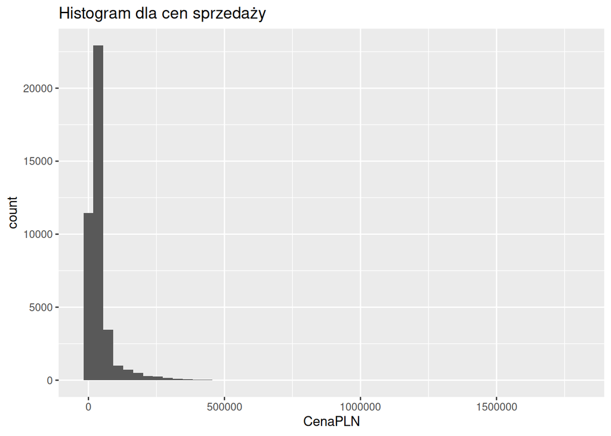

```r
ggplot(data=database) + geom_histogram(aes(x=CenaPLN), bins = 50) + ggtitle("Histogram dla cen sprzedaży");
```

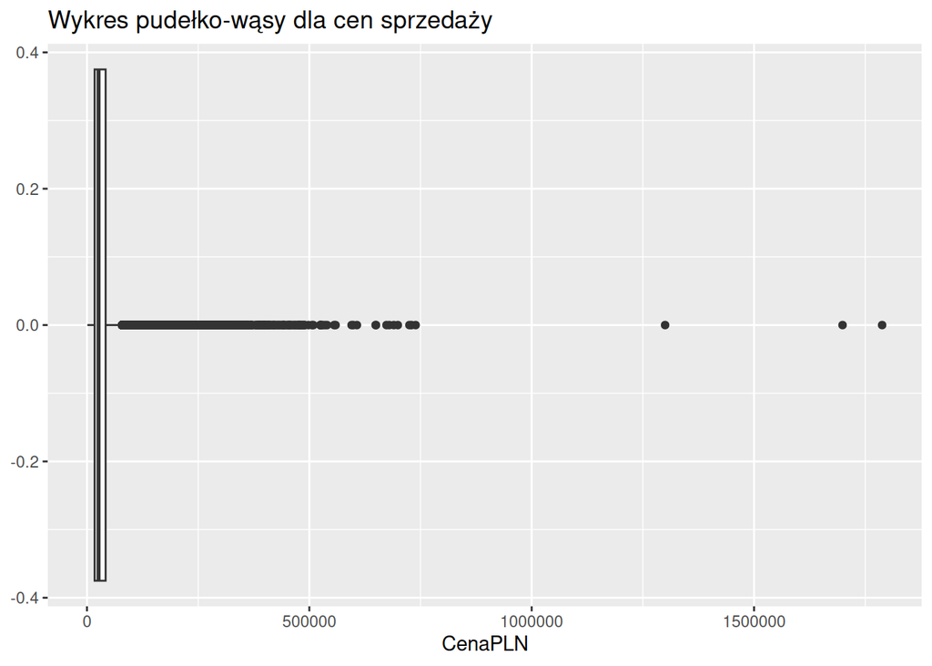

```r
ggplot(data=database) + geom_boxplot(aes(x=CenaPLN)) + ggtitle("Wykres pudełko-wąsy dla cen sprzedaży");
```

# IV - Obserwacje odstające

Obserwacja odstająca, element odstający – obserwacja relatywnie odległa od pozostałych elementów próby. Innymi słowy, posiadająca nietypową wartość zmiennej niezależnej (objaśniającej) lub nietypowe wartości obydwu zmiennych – zależnej (objaśnianej) i objaśniającej (objaśniających w analizie regresji wielokrotnej).

## Redukcja danych odstających zgodnie z regułą 3 sigma

Redukcja danych zgodnie z regułą 3 sigma.

Identyfikacja danych odstających za pomocą reguły trzech sigm:

1. Obliczenie średniej (μ): Najpierw oblicza się średnią dla danego zbioru danych.
2. Obliczenie odchylenia standardowego (σ): Następnie oblicza się odchylenie standardowe, które mierzy, jak bardzo dane rozpraszają się wokół średniej.
3. Ustalenie zakresu trzech sigm: Wartości, które znajdują się poza zakresem trzech sigm (μ ± 3σ), są uznawane za dane odstające.

```r
mean_price = mean(database$CenaPLN);
sd_price   = sd(database$CenaPLN);

lower_bound <- mean_price - 3 * sd_price;
upper_bound <- mean_price + 3 * sd_price;

cat("Wyznacznowe granice metodą 3 sigma \n")
```

```
## Wyznacznowe granice metodą 3 sigma
```

```r
cat("Dolna granica ", lower_bound, ", górna granica ", upper_bound, "\n");
```

```
## Dolna granica  -113194.6 , górna granica  194891.3
```

```r
cat("Dolna granica wykracza poza osiągane wartości kwot sprzedaży (ujemna wartość). \n")
```

```
## Dolna granica wykracza poza osiągane wartości kwot sprzedaży (ujemna wartość).
```

```r
upper_price_example = database[which(database$CenaPLN >= upper_bound),];
head(upper_price_example[order(upper_price_example$CenaPLN, decreasing = TRUE),])
```

```
##       NrOferty CenaPLN  KM         Marka      Model LiczbaDrzwi
## 14353    14353 1788000 626 Mercedes-Benz        SLR         4/5
## 36278    36278 1699000 800 Mercedes-Benz   S 63 AMG         4/5
## 14159    14159 1300000 626 Mercedes-Benz        SLR         2/3
## 27512    27512  739000 571 Mercedes-Benz SLS 63 AMG         2/3
## 28662    28662  730000 563 Mercedes-Benz SLS 63 AMG         2/3
## 28663    28663  725000 563 Mercedes-Benz SLS 63 AMG         2/3
##       PojemnoscSkokowa PrzebiegKm RodzajPaliwa RokProdukcji              Kolor
## 14353             5439          1      benzyna         2009    czarny-metallic
## 36278             6233       1500      benzyna         2011    czarny-metallic
## 14159             5439       2098      benzyna         2007 granatowy-metallic
## 27512             6208       5000      benzyna         2010 grafitowy-metallic
## 28662             6208        380      benzyna         2011    czarny-metallic
## 28663             6208        520      benzyna         2011   srebrny-metallic
##         KrajPochodzenia PojazdUszkodzony SkrzyniaBiegowManualna
## 14353            Niemcy            FALSE                  FALSE
## 36278            Niemcy            FALSE                  FALSE
## 14159            Niemcy            FALSE                  FALSE
## 27512            Polska            FALSE                  FALSE
## 28662 Stany Zjednoczone            FALSE                  FALSE
## 28663 Stany Zjednoczone            FALSE                  FALSE
```

```r
database = database[database$CenaPLN >= lower_bound & database$CenaPLN <= upper_bound,]
```

## Redukcja danych odstających regułą odstępu międzykwartylowgo

Metoda redukcji, polega na wykrywaniu i usuwaniu wartości odstających z zestawu danych. Metoda ta opiera się na kwartylach i rozstępie międzykwartylowym.

```r
Q1 = quantile(database$PrzebiegKm, 0.25);
Q3 = quantile(database$PrzebiegKm, 0.75);
IQR = Q3-Q1;
lower_bound = Q1 - 1.5*IQR #mniejsze niż
upper_bound = Q3 + 1.5*IQR #większe niż

cat("Wyznacznowe granice metodą odstępu międzykwartylowego sigma \n")
```

```
## Wyznacznowe granice metodą odstępu międzykwartylowego sigma
```

```r
cat("Dolna granica ", lower_bound, ", górna granica ", upper_bound, "\n");
```

```
## Dolna granica  -47281.25 , górna granica  303568.8
```

```r
cat("Dolna granica wykracza poza osiągane wartości kwot sprzedaży (ujemna wartość). \n")
```

```
## Dolna granica wykracza poza osiągane wartości kwot sprzedaży (ujemna wartość).
```

```r
database = database[database$PrzebiegKm >= lower_bound & database$PrzebiegKm <= upper_bound,]
```

```r
database %>% group_by(Marka) %>% summarise(liczbaSprzedanych = n(),
                                                    sredniaCena = mean(CenaPLN),
                                                    medianaCena = median(CenaPLN))
```

```
## # A tibble: 11 × 4
##    Marka         liczbaSprzedanych sredniaCena medianaCena
##    <chr>                     <int>       <dbl>       <dbl>
##  1 Audi                       3322      64178.      46900
##  2 BMW                        2217      61711.      51500
##  3 Fiat                       1923      19118.      14800
##  4 Ford                       5393      27389.      22900
##  5 Mercedes-Benz              2319      62040.      46000
##  6 Opel                       4991      24201.      22600
##  7 Peugeot                    3199      25212.      22000
##  8 Renault                    4714      21099.      17810.
##  9 Skoda                      2928      29156.      26450
## 10 Toyota                     2669      36048.      29900
## 11 Volkswagen                 6120      35673.      29900
```

### Dane po eliminacją danych odstających

```r
summarise(database,
  srednia = mean(CenaPLN),
  mediana = median(CenaPLN),
  wariancja = var(CenaPLN),
  odchylenieStd = sd(CenaPLN),
  max = max(CenaPLN),
  min = min(CenaPLN),
)
```

```
##    srednia mediana wariancja odchylenieStd    max  min
## 1 34656.67   25900 870294063      29500.75 194800 1000
```

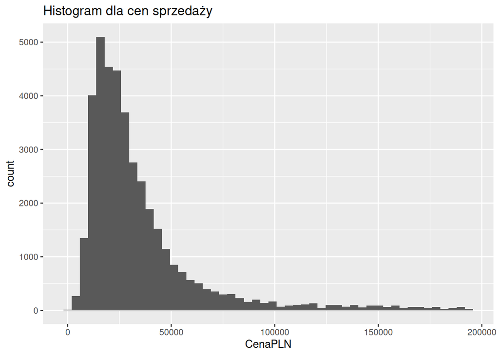

```r
ggplot(data=database) + geom_histogram(aes(x=CenaPLN), bins = 50) + ggtitle("Histogram dla cen sprzedaży");
```

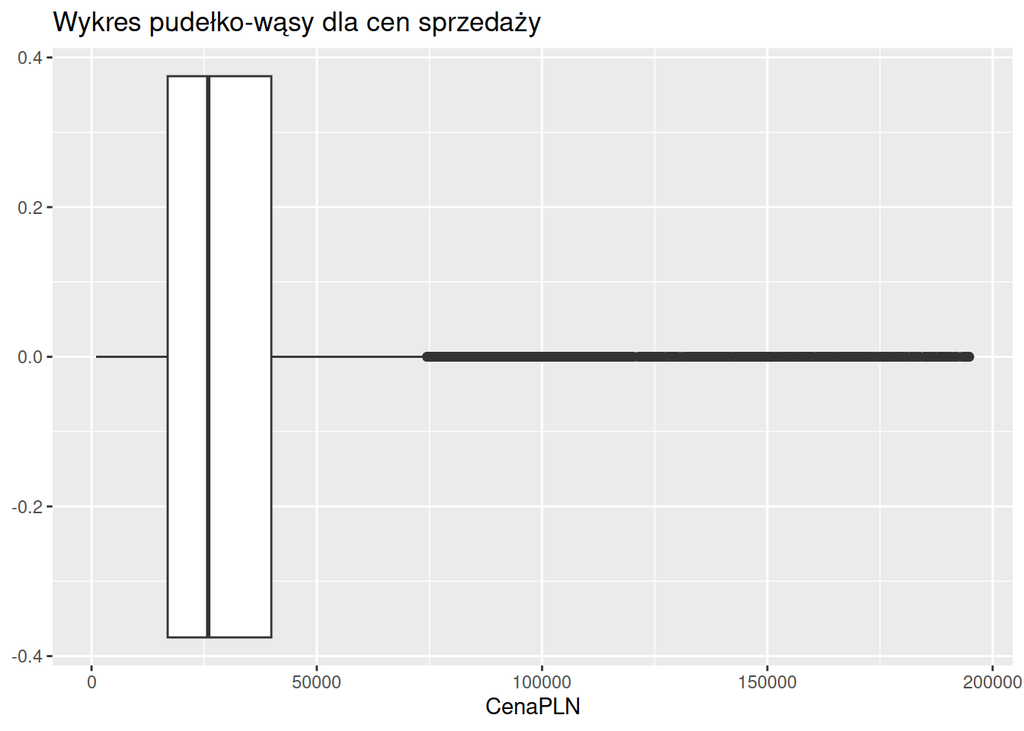

```r
ggplot(data=database) + geom_boxplot(aes(x=CenaPLN)) + ggtitle("Wykres pudełko-wąsy dla cen sprzedaży");
```

[figure not shown]

```r
ggplot(data=database, aes(sample = CenaPLN)) + stat_qq() + stat_qq_line(colour="red") + ylab("Kwantyl Teoretyczny") + xlab("Kwantyl Empiryczny") +
  ggtitle("Wykres QQ dla cen sprzedaży") + theme(axis.text.x = element_blank(), axis.text.y = element_blank()) ;
```

```r
fuelType = database %>% group_by(database$RodzajPaliwa) %>% summarise(liczba = n());
colnames(fuelType) = c("FuelType", "Count");
fuelType = fuelType[order(fuelType$Count, decreasing = TRUE),]
fuelType
```

```
## # A tibble: 6 × 2
##   FuelType               Count
##   <chr>                  <int>
## 1 olej napędowy (diesel) 26980
## 2 benzyna                11878
## 3 benzyna+LPG              883
## 4 benzyna+CNG               23
## 5 hybryda                   21
## 6 napęd elektryczny         10
```

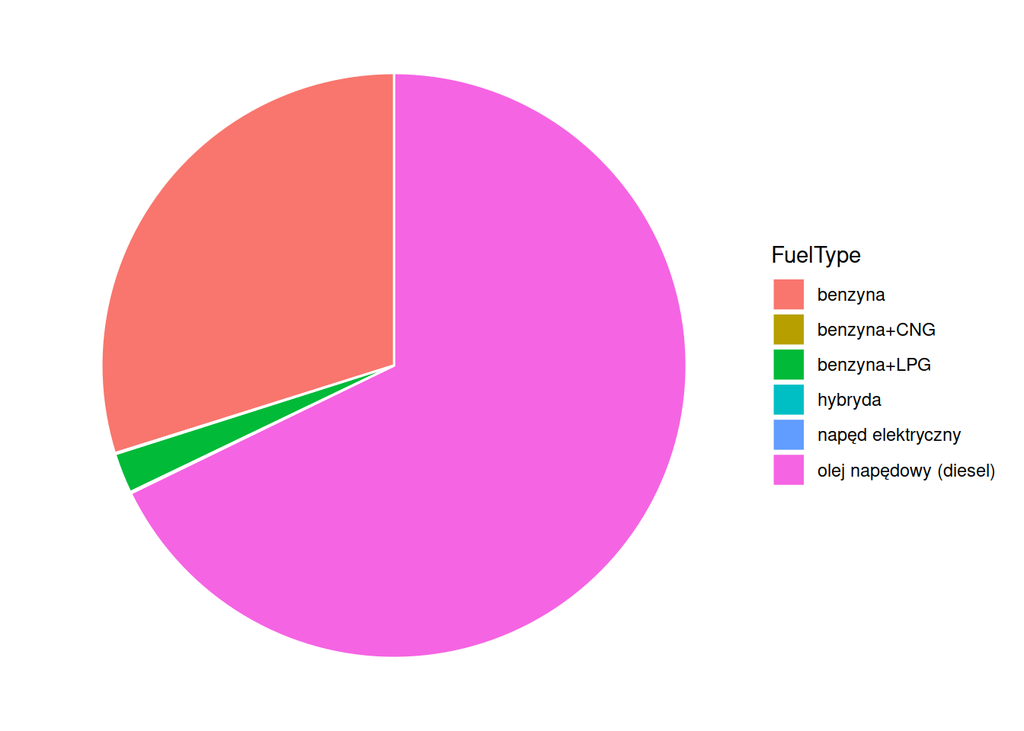

```r
ggplot(fuelType, aes(x="", y=Count, fill=FuelType)) +
  geom_bar(stat="identity", width=1, color="white") +
  coord_polar("y", start=0) + theme_void();
```

## Liczba koni mechanicznych samochodu

```r
summarise(database,
  srednia = mean(KM),
  mediana = median(KM),
  wariancja = var(KM),
  odchylenieStd = sd(KM),
  max = max(KM),
  min = min(KM),
)
```

```
##    srednia mediana wariancja odchylenieStd  max min
## 1 116.2776     106  2567.881      50.67426 1400   1
```

```r
upper_price_example = database[which(database$CenaPLN >= upper_bound),];
head(upper_price_example[order(upper_price_example$CenaPLN, decreasing = TRUE),])
```

```
##  [1] NrOferty               CenaPLN                KM
##  [4] Marka                  Model                  LiczbaDrzwi
##  [7] PojemnoscSkokowa       PrzebiegKm             RodzajPaliwa
## [10] RokProdukcji           Kolor                  KrajPochodzenia
## [13] PojazdUszkodzony       SkrzyniaBiegowManualna
## <0 wierszy> (lub 'row.names' o zerowej długości)
```

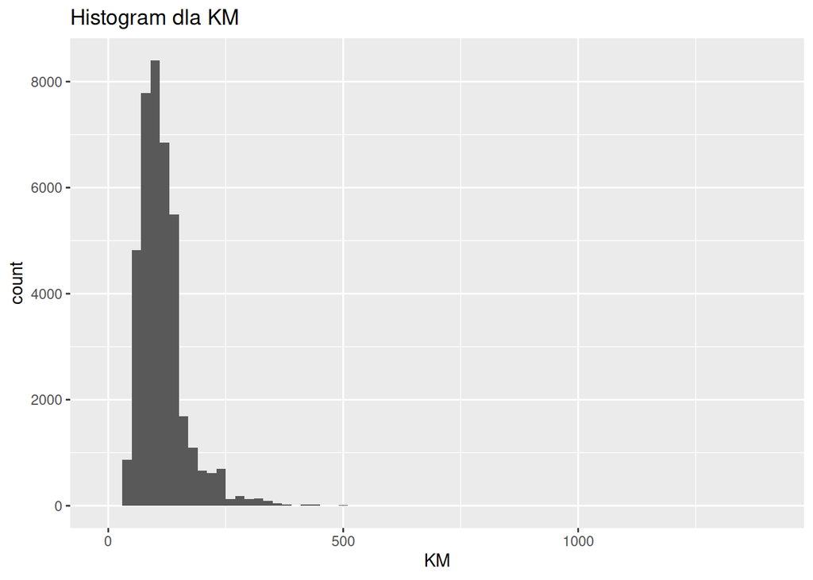

```r
ggplot(data=database)+ geom_histogram(aes(x=KM), binwidth = 20) + ggtitle("Histogram dla KM")
```

# V - Wyznaczanie prawdopodobieństw dla zmiennej

## Rozkłady dyskretne

### Dwumianowy

```r
#Generowanie próbki
set.seed(42)
N <- 1000
n <- 20
p <- 0.4
X <- rbinom(N, n, p)

#Prawdopodobieństwa
pbinom(8, n, p) - pbinom(7, n, p) # P(X=8) p. punktowe
```

```
## [1] 0.1797058
```

```r
pbinom(10, n, p) # P(X<=10) p. przedziałowe
```

```
## [1] 0.8724788
```

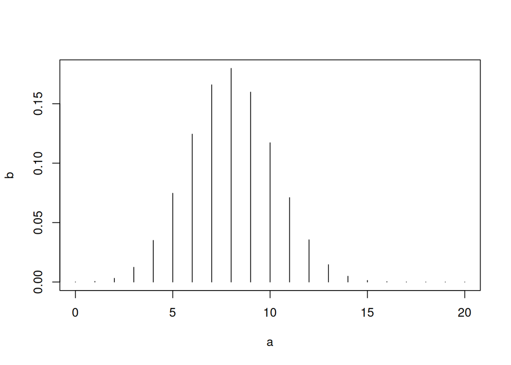

```r
#Wykres gęstości
a <- seq(0, n, by = 1)
b <- dbinom(a, n, p)
plot(a,b, type="h")
```

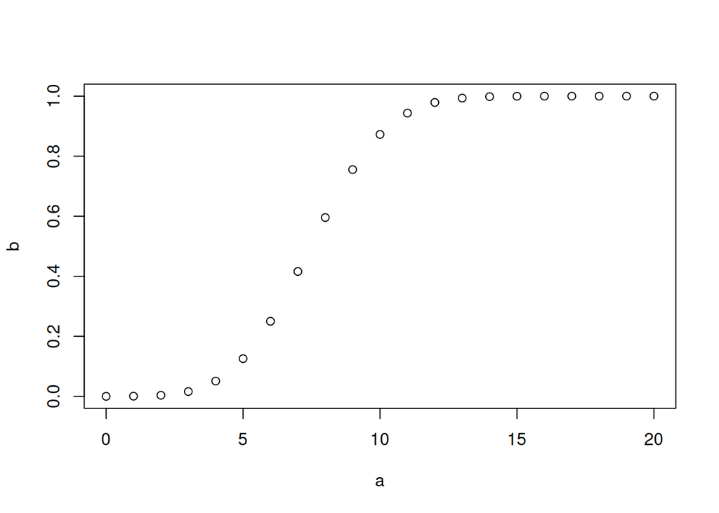

```r
#Wykres dystrybuanty
a <- seq(0, n, by = 1)
b <- pbinom(a, n, p)
plot(a,b)
```

### Rozkład Poissona

```r
#Generowanie próbki
N <- 1000
lambda <- 200
X <- rpois(N, lambda)

#Prawdopodobieństwa
ppois(190, lambda) - ppois(189, lambda) # P(X=190)
```

```
## [1] 0.02243432
```

```r
ppois(190, lambda) #(P<=190)
```

```
## [1] 0.2529326
```

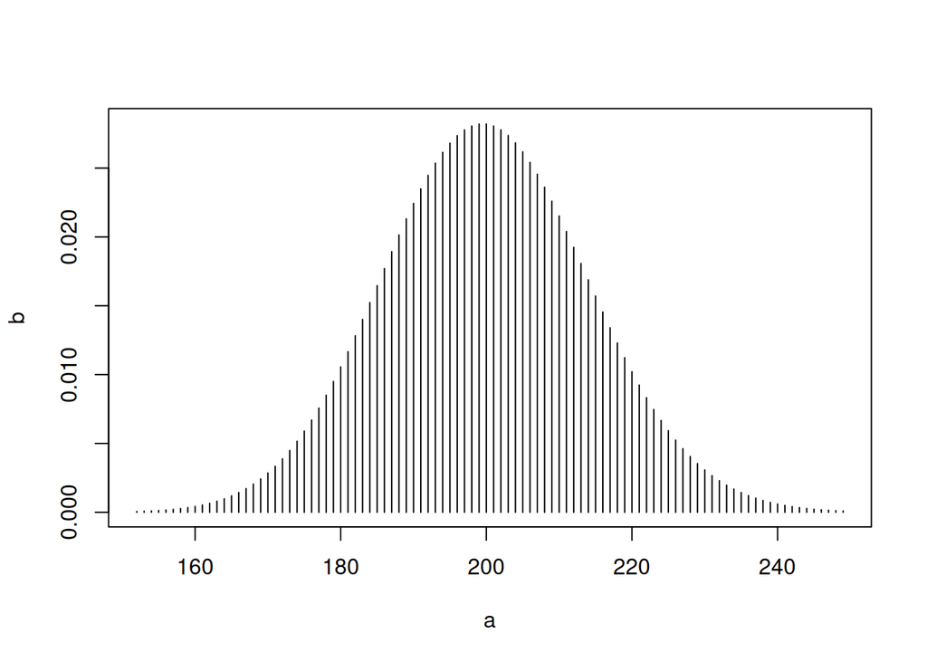

```r
#Wykres gęstości
a <- seq(min(X), max(X), by = 1)
b <- dpois(a, lambda)
plot(a,b, type="h")
```

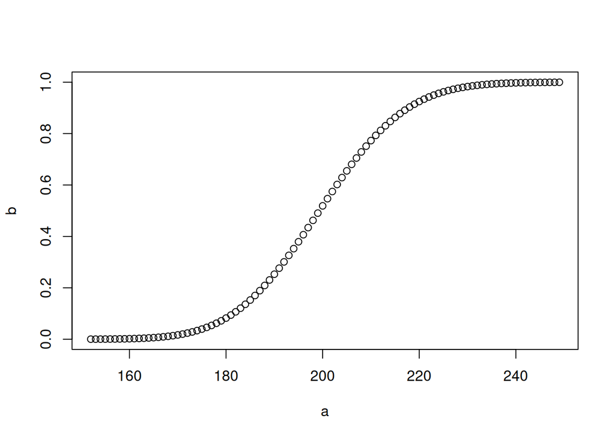

```r
#Wykres dystrybuanty
a <- seq(min(X), max(X), by = 1)
b <- ppois(a, lambda)
plot(a,b)
```

## Rozkłady ciągłe

### Rozkład normalny

```r
#Generowanie próbki
N <- 1000
mu <- 7 # średnia
sigma <- 10 # odchylenie standardowe
X <- rnorm(N, mu, sigma)

#Prawdopodobieństwa
#Prawd. punktowe w rozkładzie ciągłym = 0
pnorm(10, mu, sigma) # P(X<=10) p. przedziałowe
```

```
## [1] 0.6179114
```

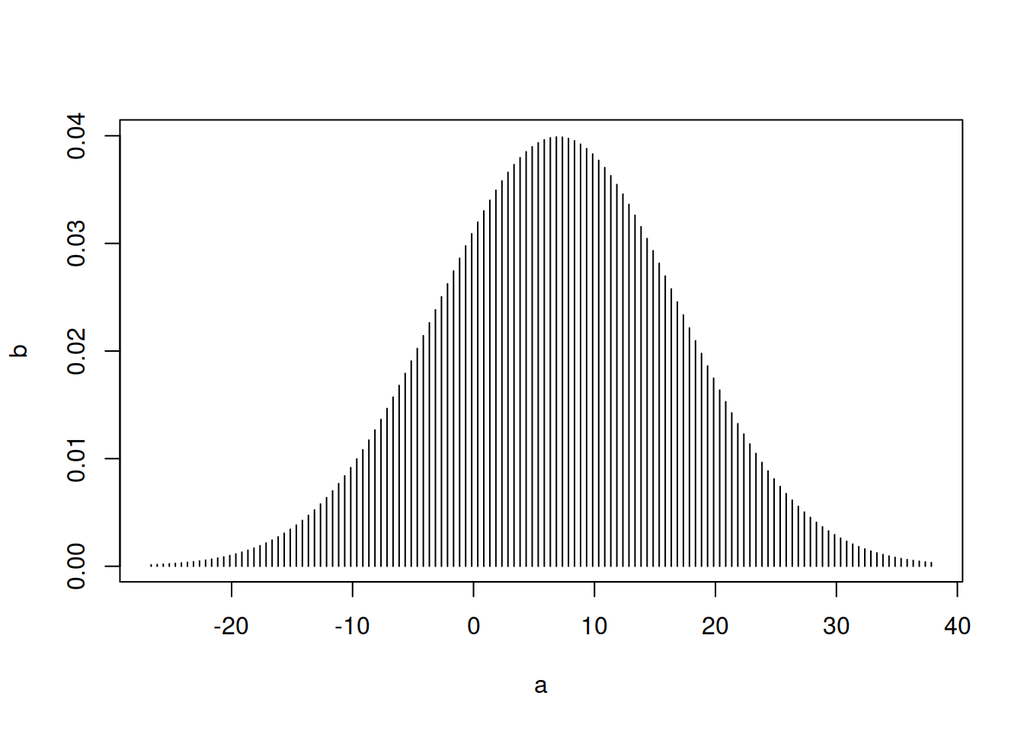

```r
#Wykres gęstości
a <- seq(min(X), max(X), by = 0.5)
b <- dnorm(a, mu, sigma)
plot(a,b, type="h")
```

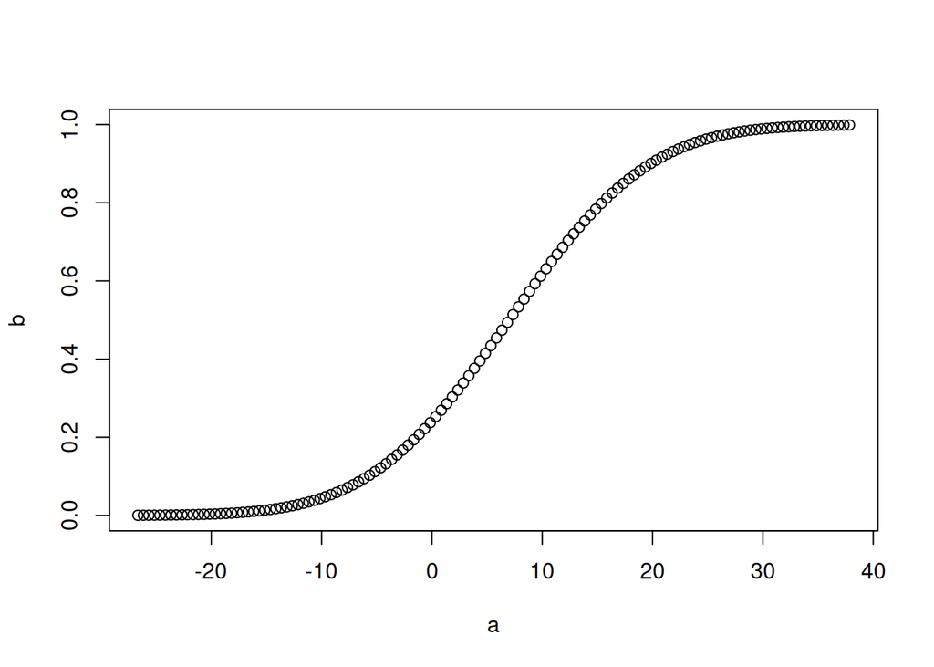

```r
#Wykres dystrybuanty
a <- seq(min(X), max(X), by = 0.5)
b <- pnorm(a, mu, sigma)
plot(a,b)
```

### Rozkład Beta

```r
#Generowanie próbki
N <- 1000
alpha <- 0.5
beta <- 0.5
X <- rbeta(N, alpha, beta)

#Prawdopodobieństwa
#Prawd. punktowe w rozkładzie ciągłym = 0
pbeta(0.7, alpha, beta) # P(X<=0.7) p. przedziałowe
```

```
## [1] 0.6309899
```

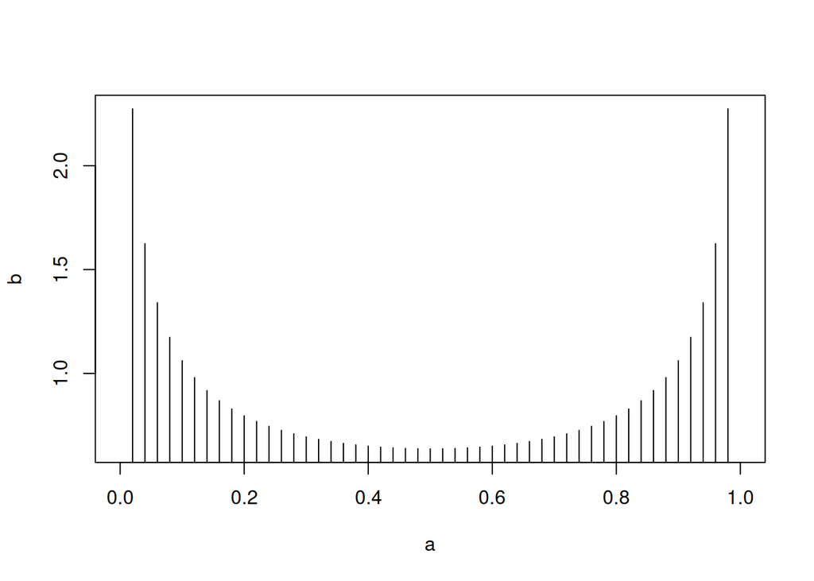

```r
#Wykres gęstości
a <- seq(0, 1, by = 0.02)
b <- dbeta(a, alpha, beta)
plot(a,b, type="h")
```

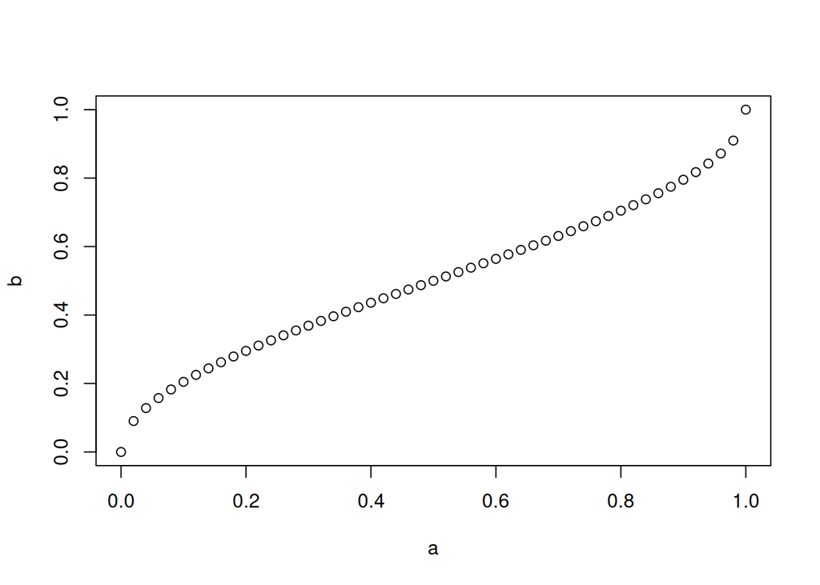

```r
#Wykres dystrybuanty
a <- seq(0, 1, by = 0.02)
b <- pbeta(a, alpha, beta)
plot(a,b)
```

# VI - Budowa macierzy z bazy danych

Do zbudowanie macierzy wykorzystano wszystkie dostępne numeryczne dane tj. *CenaPLN*, *KM*, *PrzebiegKm*, *RokProdukcji*, *PojemnoscSkokowa*. Dzięki temu możliwe jest wyznaczenie macierzy korelacji pomiędzy danymi.

```r
# Select data
vi_database = select(filter(database, PojazdUszkodzony==FALSE & SkrzyniaBiegowManualna == TRUE),
                     c("CenaPLN", "KM", "PrzebiegKm", "RokProdukcji", "PojemnoscSkokowa"))

#Display head
head(vi_database)
```

```
##   CenaPLN  KM PrzebiegKm RokProdukcji PojemnoscSkokowa
## 1   27900 150      80840         2005             1900
## 2   28000 116     166000         2004             2000
## 3   25500 150     112000         2002             1781
## 4   29900 109      42000         2005             1991
## 5   29800 207     169000         2004             2946
## 6   21400 122     160000         2003             1800
```

```r
# Dimension
vi_dim <- dim(vi_database);
cat("Rozmiar macierzy:", vi_dim[1], "x", vi_dim[2]);
```

```
## Rozmiar macierzy: 32646 x 5
```

```r
# Columns mean
vi_means = round(colMeans(vi_database), 3);
cat(paste(names(vi_means), vi_means, sep = " : ", collapse = ",\n"))
```

```
## CenaPLN : 29250.103,
## KM : 104.378,
## PrzebiegKm : 127080.842,
## RokProdukcji : 2005.089,
## PojemnoscSkokowa : 1739.627
```

```r
# Correlation
vi_corr_matrix = cor(vi_database);
print(vi_corr_matrix)
```

```
##                     CenaPLN        KM PrzebiegKm RokProdukcji PojemnoscSkokowa
## CenaPLN           1.0000000 0.5096861 -0.3659806   0.62332163       0.38550218
## KM                0.5096861 1.0000000  0.1047219   0.07592120       0.73909520
## PrzebiegKm       -0.3659806 0.1047219  1.0000000  -0.57854449       0.30351805
## RokProdukcji      0.6233216 0.0759212 -0.5785445   1.00000000      -0.09648703
## PojemnoscSkokowa  0.3855022 0.7390952  0.3035180  -0.09648703       1.00000000
```

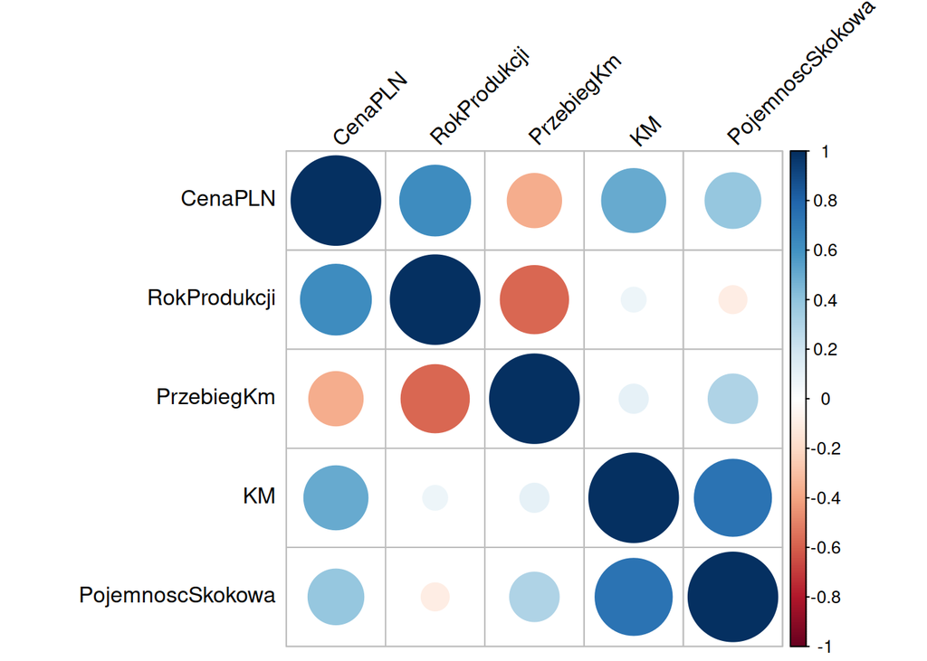

```r
corrplot(vi_corr_matrix, order = "hclust",
         tl.col = "black", tl.srt = 45)
```

Jak można zaobserwować: - *CenaPLN* skorelowana jest z *RokProdukcji* (silnie), *KM*, *PojemnoscSkokowa* oraz odwrotnie z *PrzebiegKM*,  
- *PojemnoscSkokowa* jest silnie skorelowana z ilością *KM* (większa pojemność -> więcej KM), - *PrzebiegKM* jest odwrotnie skorelowany z *RokProdukcji* (starszy samochód -> większy przebieg).

# VII - Przedziały ufności

W tej sekcji przedstawione zostaną badania określające przedziały ufności z różnym stopniem ‘zaufania’. Oznacza to, że jeśli grupa badana była zgromadzona w sposób losowy to rzeczywisty parametr populacji z z określonym stopniem ‘zaufania’ znajduje się w tym przedziale.

## Zmienna numeryczna

W celu określnenia przedziałów ufności zmiennej numerycznej wybrano cechę *CenaPLN*. Przedział ufności dla średniej:

```r
# Meta data
# Confidence level 0.9, 0.95, 0.99
confidence_level = c(0.9, 0.95, 0.99);

# Basic data
vii_price_mean = mean(database$CenaPLN);
vii_price_sd = sd(database$CenaPLN);
n = length(database$CenaPLN);

# Mean confidence function
mean_confidence <- function(mean, sd, n, confidence_level) {
  alpha = 1 - confidence_level;
  offset = qnorm(1 - alpha / 2) * sd / sqrt(n);
  lower_bound = mean - offset;
  upper_bound = mean + offset;
  return(c(lower_bound, upper_bound));
};

# Calculate confidence
mean_confidence_intervals = sapply(confidence_level, function(conf_level) {
  mean_confidence(vii_price_mean, vii_price_sd, n, conf_level)
});

# Create matrix
mean_confidence_intervals = t(mean_confidence_intervals);
rownames(mean_confidence_intervals) = paste0("Poziom ufności: ", confidence_level);
colnames(mean_confidence_intervals) = c("Dolny przedział", "Górny przedział");

# Display
print("Przedziały ufności średniej dla różnych poziomów ufności:");
```

```
## [1] "Przedziały ufności średniej dla różnych poziomów ufności:"
```

```r
print(mean_confidence_intervals);
```

```
##                      Dolny przedział Górny przedział
## Poziom ufności: 0.9         34413.42        34899.92
## Poziom ufności: 0.95        34366.82        34946.52
## Poziom ufności: 0.99        34275.75        35037.59
```

```r
# Meta data
# Confidence level 0.9, 0.95, 0.99
confidence_level = c(0.9, 0.95, 0.99);

# SD confidence function
sd_confidence <- function(mean, n, confidence_level) {
  alpha = 1 - confidence_level;
  offset = qnorm(1 - alpha / 2) / sqrt(2*n);
  lower_bound = mean / (1 + offset);
  upper_bound = mean / (1 - offset);
  return(c(lower_bound, upper_bound));
};

# Calculate confidence
sd_confidence_intervals = sapply(confidence_level, function(conf_level) {
  sd_confidence(vii_price_mean, n, conf_level);
});

# Create matrix
sd_confidence_intervals = t(sd_confidence_intervals);
rownames(sd_confidence_intervals) = paste0("Poziom ufności: ", confidence_level);
colnames(sd_confidence_intervals) = c("Dolny przedział", "Górny przedział");

# Display
print("Przedziały ufności odchylenia standardowego dla różnych poziomów ufności:");
```

[output not shown]

```r
print(sd_confidence_intervals);
```

```
##                      Dolny przedział Górny przedział
## Poziom ufności: 0.9         34455.78        34859.92
## Poziom ufności: 0.95        34417.56        34899.13
## Poziom ufności: 0.99        34343.11        34976.01
```

## Przedział ufności dla zmiennej jakościowej (frakcyjna)

Do wyznaczenia przedziału ufności dla zmiennej *PojazdUszkodzony* (rozkład Bernoulliego)

```r
# Meta data
# Confidence level 0.9, 0.95, 0.99
confidence_level = c(0.9, 0.95, 0.99);

# Basic data
vii_positive = sum(database$PojazdUszkodzony == TRUE);
vii_all      = length(database$PojazdUszkodzony);

mean_bool_confidence <- function(m, n, confidence_level) {
  alpha = 1 - confidence_level;
  mn = m / n;
  offset = qnorm(1 - alpha / 2) * sqrt(mn * (1-mn)) / sqrt(n);
  lower_bound = mn - offset;
  upper_bound = mn + offset;
  return(c(lower_bound, upper_bound));
};

# Calculate confidence
confidence_intervals = sapply(confidence_level, function(conf_level) {
  mean_bool_confidence(vii_positive, vii_all, conf_level);
});

# Create matrix
confidence_intervals = t(confidence_intervals);
rownames(confidence_intervals) = paste0("Poziom ufności: ", confidence_level);
colnames(confidence_intervals) = c("Dolny przedział", "Górny przedział");

# Display
print("Przedziały ufności dla frakcji dla różnych poziomów ufności (Udział pojazdów uszkodzonych):");
```

```
## [1] "Przedziały ufności dla frakcji dla różnych poziomów ufności (Udział pojazdów uszkodzonych):"
```

```r
print(confidence_intervals);
```

```
##                      Dolny przedział Górny przedział
## Poziom ufności: 0.9       0.03528564      0.03839196
## Poziom ufności: 0.95      0.03498810      0.03868950
## Poziom ufności: 0.99      0.03440657      0.03927103
```

# VII - Testowanie hipotez

## Zmienne jakościowe

### Test niezależności

```r
print(table(database$KrajPochodzenia, database$Marka));
```

```
##
##                     Audi  BMW Fiat Ford Mercedes-Benz Opel Peugeot Renault
##   Austria             48   38   41   75            19   67      47      73
##   Belgia             204  154   51  246            86  427     171     264
##   Czechy             123  125   56  254           102  191     147     226
##   Dania                2    1    5   18             2   31      16       6
##   Estonia              0    0    0    1             0    0       0       0
##   Francja            139  102  101  402           117  322     817    1116
##   Grecja               0    0    0    0             0    0       0       0
##   Hiszpania            4    7    3   27             7   34       7      10
##   Holandia            27   28   21  111            21  141      84     140
##   Irlandia             0    0    0    0             1    2       0       0
##   Islandia             0    0    0    0             0    1       0       0
##   Kanada               4    5    0    3             3    0       0       0
##   Luksemburg          14   10   11   14             7   27      19      30
##   Niemcy            2080 1210  400 2096          1150 2119     667    1436
##   Norwegia             0    0    0    0             0    1       0       0
##   Polska             423  301 1133 1842           641 1459    1098    1242
##   Rosja                0    0    0    0             0    0       0       0
##   Rumunia              0    0    0    0             0    0       0       2
##   Slowacja             1    4    0    2             1    0       0       0
##   Stany Zjednoczone   90   64    0  101            72    2       0       0
##   Szwajcaria          55   35   10   36            15   41      19      39
##   Szwecja              5    1    0    3             3    2       1       1
##   Wegry                0    0    0    1             0    0       1       0
##   Wielka Brytania     29   23    4   15            15   17      13      19
##   Wlochy              74  109   87  146            57  107      92     110
##
##                     Skoda Toyota Volkswagen
##   Austria              32     31        108
##   Belgia               88    137        305
##   Czechy              953    142        243
##   Dania                 2     36         22
##   Estonia               0      0          1
##   Francja              81    176        410
##   Grecja                0      1          0
##   Hiszpania             5      7         17
##   Holandia             29     44        161
##   Irlandia              0      0          1
##   Islandia              0      0          0
##   Kanada                0      2          4
##   Luksemburg            5     12         22
##   Niemcy              531    580       3271
##   Norwegia              0      2          1
##   Polska             1154   1297       1303
##   Rosja                 0      0          1
##   Rumunia               0      0          0
##   Slowacja              3      1          1
##   Stany Zjednoczone     0    119         73
##   Szwajcaria           15     11         30
##   Szwecja               0      1          6
##   Wegry                 0      0          0
##   Wielka Brytania       7      5         39
##   Wlochy               23     65        101
```

```r
vii_test = chisq.test(table(database$Marka, database$SkrzyniaBiegowManualna));
print(vii_test)
```

```
##
##  Pearson's Chi-squared test
##
## data:  table(database$Marka, database$SkrzyniaBiegowManualna)
## X-squared = 8406.9, df = 10, p-value < 2.2e-16
```

### Test proporcji

Test proprcji w którym wykorzystano liczbę samochodów uszkodzonych oraz kraj pochodzenie. H0 - odsetek samochodów uszkodzonych jest niezależny od kraju pochodzenia.

```r
vii_proporcja = database %>% group_by(database$KrajPochodzenia) %>% summarise(liczba = n());
vii_proporcja$uszkodzonych = table(database$KrajPochodzenia, database$PojazdUszkodzony)[,2];
vii_proporcja = vii_proporcja %>% filter(liczba > 500);
vii_test = prop.test(x = vii_proporcja$uszkodzonych, n = vii_proporcja$liczba);
print(vii_test);
```

```
##
##  9-sample test for equality of proportions without continuity
##  correction
##
## data:  vii_proporcja$uszkodzonych out of vii_proporcja$liczba
## X-squared = 1059.7, df = 8, p-value < 2.2e-16
## alternative hypothesis: two.sided
## sample estimates:
##     prop 1     prop 2     prop 3     prop 4     prop 5     prop 6     prop 7
## 0.06735751 0.05766526 0.00117096 0.11895321 0.02850062 0.02683398 0.02009585
##     prop 8     prop 9
## 0.06333973 0.02265705
```

### Zmienne ilościowe

Testowanie normalności względem ceny, test pozwala na potwierdzenie tezy o normalności rozkładu. H0 - doświadczenie ma rozkład normalny.

```r
vii_test = ad.test(database$CenaPLN);
print(vii_test);
```

```
##
##  Anderson-Darling normality test
##
## data:  database$CenaPLN
## A = 3123.5, p-value < 2.2e-16
```

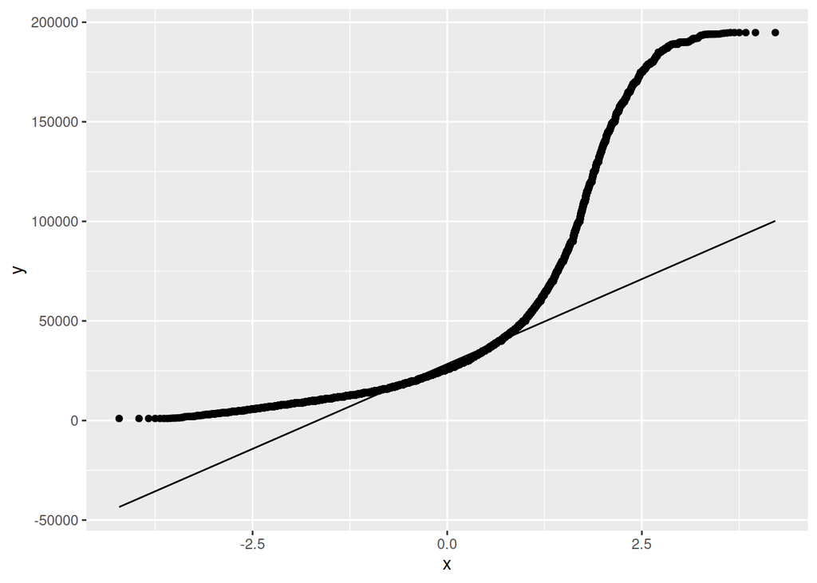

```r
ggplot(database, aes(sample = CenaPLN)) +
  stat_qq() +
  stat_qq_line();
```

Cena nie jest zmienną o rozkładzie normalnym.

### Test Wilcoxona

Ze względu na to, iż cena nie jest zmienną o rozkładzie normalnym. Wykorzystujemy nieparametryczny test Wilcoxona. H0 - średnia jest równa 34656.

```r
wilcox.test(x = database$CenaPLN, mu = 34656)
```

```
##
##  Wilcoxon signed rank test with continuity correction
##
## data:  database$CenaPLN
## V = 277239234, p-value < 2.2e-16
## alternative hypothesis: true location is not equal to 34656
```

# IX - Regresja liniowa i inne

## Modele dla jednej zmiennej

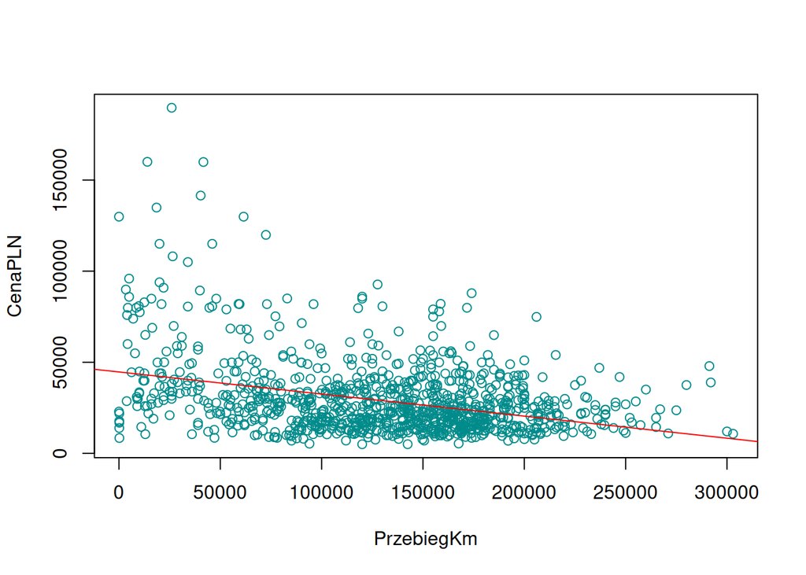

```r
ix_database = select(filter(database, PojazdUszkodzony==FALSE & SkrzyniaBiegowManualna == TRUE),
                     c("CenaPLN", "PrzebiegKm"))
model = lm(CenaPLN ~ . , data = ix_database)
ix_sample = ix_database[sample(nrow(ix_database), size=1000),]
plot(CenaPLN ~ PrzebiegKm,  data=ix_sample, col = 'darkcyan')
abline(model, col="red")
```

```r
summary(model);
```

```
##
## Call:
## lm(formula = CenaPLN ~ ., data = ix_database)
##
## Residuals:
##    Min     1Q Median     3Q    Max
## -40733 -11549  -3678   6986 152257
##
## Coefficients:
##               Estimate Std. Error t value Pr(>|t|)
## (Intercept)  4.465e+04  2.398e+02  186.17   <2e-16 ***
## PrzebiegKm  -1.212e-01  1.706e-03  -71.05   <2e-16 ***
## ---
## Signif. codes:  0 '***' 0.001 '**' 0.01 '*' 0.05 '.' 0.1 ' ' 1
##
## Residual standard error: 18550 on 32644 degrees of freedom
## Multiple R-squared:  0.1339, Adjusted R-squared:  0.1339
## F-statistic:  5049 on 1 and 32644 DF,  p-value: < 2.2e-16
```

```r
print(model$coefficients);
```

```
##   (Intercept)    PrzebiegKm
## 44651.6424984    -0.1211948
```

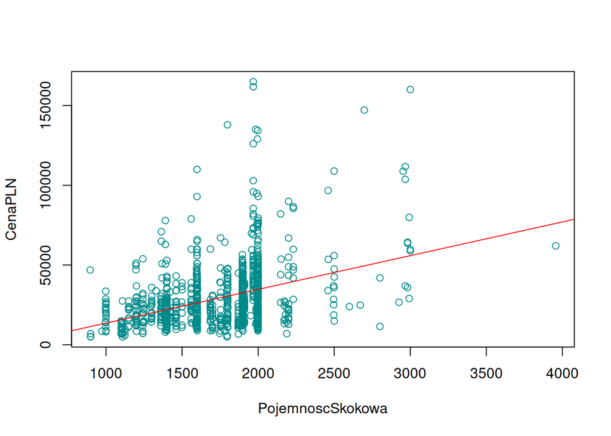

```r
ix_database = select(filter(database, PojazdUszkodzony==FALSE & SkrzyniaBiegowManualna == TRUE),
                     c("CenaPLN", "PojemnoscSkokowa"))
model = lm(CenaPLN ~ . , data = ix_database)
ix_sample = ix_database[sample(nrow(ix_database), size=1000),]
plot(CenaPLN ~ PojemnoscSkokowa,  data=ix_sample, col = 'darkcyan')
abline(model, col="red")
```

```r
summary(model);
```

```
##
## Call:
## lm(formula = CenaPLN ~ ., data = ix_database)
##
## Residuals:
##     Min      1Q  Median      3Q     Max
## -106802  -11243   -3490    6365  159245
##
## Coefficients:
##                    Estimate Std. Error t value Pr(>|t|)
## (Intercept)      -7527.2394   497.7274  -15.12   <2e-16 ***
## PojemnoscSkokowa    21.1409     0.2801   75.49   <2e-16 ***
## ---
## Signif. codes:  0 '***' 0.001 '**' 0.01 '*' 0.05 '.' 0.1 ' ' 1
##
## Residual standard error: 18390 on 32644 degrees of freedom
## Multiple R-squared:  0.1486, Adjusted R-squared:  0.1486
## F-statistic:  5698 on 1 and 32644 DF,  p-value: < 2.2e-16
```

```r
print(model$coefficients);
```

```
##      (Intercept) PojemnoscSkokowa
##      -7527.23942         21.14093
```

## Modele dla 2 zmiennych

```r
ix_database = select(filter(database, PojazdUszkodzony==FALSE & SkrzyniaBiegowManualna == TRUE),
                     c("CenaPLN", "PrzebiegKm", "PojemnoscSkokowa"))
model = lm(CenaPLN ~ . , data = ix_database)

plot3d(model, col='darkcyan', plane.col = 'red')
rglwidget()
```

[interactive chart not shown]

```r
summary(model);
```

```
##
## Call:
## lm(formula = CenaPLN ~ ., data = ix_database)
##
## Residuals:
##     Min      1Q  Median      3Q     Max
## -156582   -8871   -1542    6472  138780
##
## Coefficients:
##                    Estimate Std. Error  t value Pr(>|t|)
## (Intercept)      -5.437e+02  4.200e+02   -1.294    0.196
## PrzebiegKm       -1.762e-01  1.483e-03 -118.785   <2e-16 ***
## PojemnoscSkokowa  3.000e+01  2.456e-01  122.129   <2e-16 ***
## ---
## Signif. codes:  0 '***' 0.001 '**' 0.01 '*' 0.05 '.' 0.1 ' ' 1
##
## Residual standard error: 15370 on 32643 degrees of freedom
## Multiple R-squared:  0.4056, Adjusted R-squared:  0.4055
## F-statistic: 1.114e+04 on 2 and 32643 DF,  p-value: < 2.2e-16
```

```r
print(model$coefficients);
```

```
##      (Intercept)       PrzebiegKm PojemnoscSkokowa
##     -543.7320918       -0.1761712       29.9959737
```

## Drzewa decyzyjne

```r
ix_database = select(filter(database, PojazdUszkodzony==FALSE & SkrzyniaBiegowManualna == TRUE),
                     c("CenaPLN", "RokProdukcji", "PojemnoscSkokowa"))
ix_data_split = initial_split(ix_database, prop = 0.75);
ix_train_data <- training(ix_data_split);
ix_test_data <- testing(ix_data_split);

tree_spec <- decision_tree() %>%
 set_engine("rpart") %>%
 set_mode("regression")

tree_fit <- tree_spec %>%
 fit(CenaPLN ~ ., data = ix_train_data)

predictions <- tree_fit %>%
 predict(ix_test_data) %>%
 pull(.pred)

metrics <- metric_set(rmse, rsq)
model_performance <- ix_test_data %>%
 mutate(predictions = predictions) %>%
 metrics(truth = CenaPLN, estimate = predictions)

print(model_performance)
```

```
## # A tibble: 2 × 3
##   .metric .estimator .estimate
##   <chr>   <chr>          <dbl>
## 1 rmse    standard   11106.
## 2 rsq     standard       0.677
```

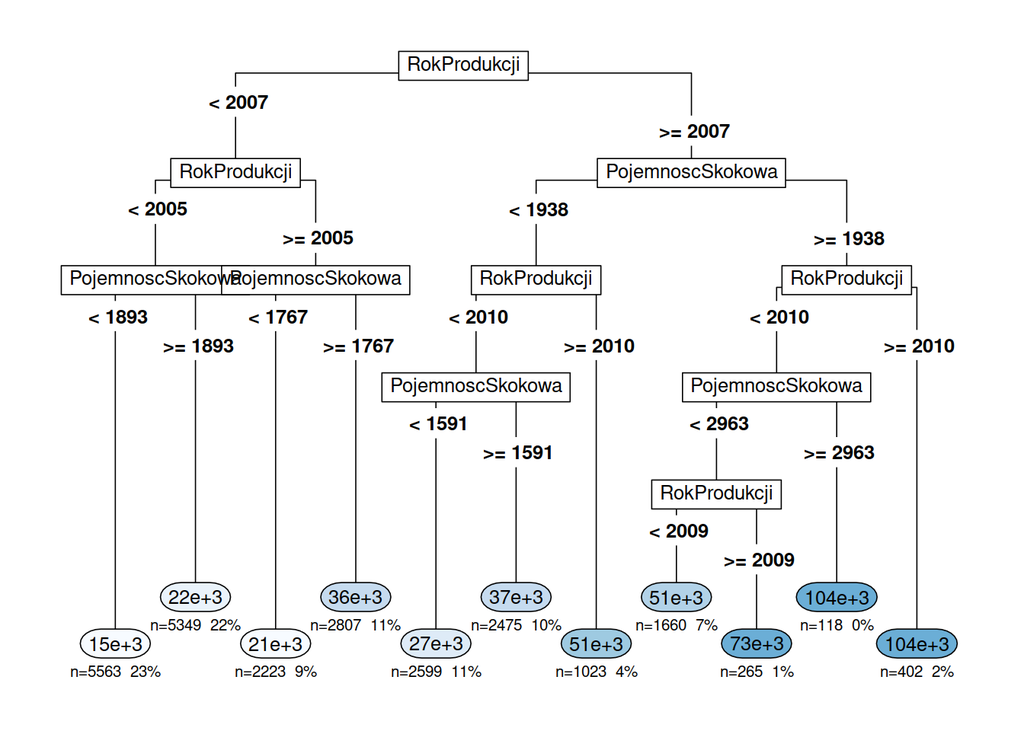

```r
rpart.plot(tree_fit$fit, type = 5, extra = 101, under = TRUE, cex = 0.8, box.palette = "auto")
```